# Proyecto 2

Carlos Angel, Pablo Donado

2025-05-25

# **Introducción**

El documento contiguo presenta un análisis de un conjunto de datos con información acerca de cincuenta jugadores de la NBA.

## Librerías

### Espacio de Trabajo

```r
setwd("C:/Users/carlo/OneDrive/Escritorio/data mining/Proyecto_2/Proyecto_unsupervised_learning")
#setwd("C:/Users/josep/OneDrive - UVG/SEMESTRE V/Data Mining/PROYECTO_FINAL_GITHUB/Proyecto_unsupervised_learning")
```

## Importación de Datos

```r
df <- read.csv("nba_players_2023_clustering (1).csv")
```

### Transformación del Dataset

#### Adición de Variables (Columnas)

Se sugiere agregar una columna que describa la región a la que pertenece cada jugador, así como un campo que indique la habilidad del jugador (nivel de jugador) en función del rendimiento por minuto.

```r
df <- df %>%
  mutate(region = case_when(
    nationality == "USA" ~ "America del Norte",
    nationality == "Canada" ~ "America del Norte",
    nationality == "Mexico" ~ "America del Norte",
    nationality == "Australia" ~ "Oceania",
    nationality == "USA/Australia" ~ "America del Norte / Oceania",
    nationality == "Japan" ~ "Asia",
    nationality == "Finland" ~ "Europa",
    nationality == "Greece" ~ "Europa",
    nationality == "Nigeria" ~ "Africa",
    nationality == "Cameroon" ~ "Africa",
    TRUE ~ "Otra"
  ))

df <- df %>%
  mutate(rendimiento_por_minuto = (points_per_game +
                                    assists_per_game +
                                    rebounds_per_game) / minutes_played_per_game)

df <- df %>%
  mutate(nivel_jugador = case_when(
    rendimiento_por_minuto >= 1.2 ~ "Elite",
    rendimiento_por_minuto >= 1.0 ~ "Alto",
    rendimiento_por_minuto >= 0.75 ~ "Promedio",
    rendimiento_por_minuto >= 0.6 ~ "Bajo",
    TRUE ~ "Muy bajo"
  ))

df$nivel_jugador <- factor(df$nivel_jugador,
                           levels = c("Muy bajo", "Bajo", "Promedio", "Alto", "Elite"))
```

A su vez, se creó una columna que indica la conferencia a la que pertenece cada equipo.

```r
equipos <- c(
  "Orlando Magic", "Milwaukee Bucks", "Washington Wizards", "Phoenix Suns",
  "Miami Heat", "Milwaukee Bucks", "Philadelphia 76ers", "New York Knicks",
  "Sacramento Kings", "Washington Wizards", "Toronto Raptors", "Milwaukee Bucks",
  "Boston Celtics", "Boston Celtics", "New York Knicks", "Orlando Magic",
  "Utah Jazz", "Phoenix Suns", "Dallas Mavericks", "Los Angeles Lakers",
  "Oklahoma City Thunder", "Oklahoma City Thunder", "Golden State Warriors",
  "Dallas Mavericks", "Atlanta Hawks", "Chicago Bulls", "Phoenix Suns",
  "Charlotte Hornets", "Sacramento Kings", "Utah Jazz", "New York Knicks",
  "Oklahoma City Thunder", "Miami Heat", "Dallas Mavericks", "Memphis Grizzlies",
  "Los Angeles Clippers", "Dallas Mavericks", "Atlanta Hawks", "Brooklyn Nets",
  "Detroit Pistons", "Philadelphia 76ers", "San Antonio Spurs", "Dallas Mavericks",
  "Dallas Mavericks", "Chicago Bulls", "Boston Celtics", "Phoenix Suns",
  "Los Angeles Lakers", "Atlanta Hawks", "Phoenix Suns"
)


# Crear columna conferencia
df <- df %>%
  mutate(conferencia = case_when(
    team %in% c("Orlando Magic", "Milwaukee Bucks", "Washington Wizards",
                "Miami Heat", "Philadelphia 76ers", "New York Knicks",
                "Toronto Raptors", "Boston Celtics", "Atlanta Hawks",
                "Chicago Bulls", "Charlotte Hornets", "Brooklyn Nets",
                "Detroit Pistons") ~ "Eastern Conference",
    team %in% c("Phoenix Suns", "Sacramento Kings", "Utah Jazz",
                "Dallas Mavericks", "Los Angeles Lakers", "Oklahoma City Thunder",
                "Golden State Warriors", "Memphis Grizzlies",
                "Los Angeles Clippers", "San Antonio Spurs") ~ "Western Conference",
    TRUE ~ NA_character_  # Por si hay algún equipo que no esté listado
  ))
```

# **Análisis Exploratorio**

```r
table(df$conferencia)
```

```
##
## Eastern Conference Western Conference
##                 26                 24
```

#### Preguntas de exploración:

1. Cuál es la distribución de las variables.
2. ¿Qué relación existe entre puntos, asistencias, rebotes por partida con la cantidad de minutos.
3. ¿Qué relación existe entre puntos, asistencias, rebotes por partida con la edad.
4. Cuantos hay en cada clasificacion de rendimiento por minuto.
5. cuales son los jugadores en el nivel elite
6. como esta distribuido el rendimiento por minuto por conferencia
7. ¿Qué equipo tiene a los jugadores más jóvenes?
8. ¿Qué equipo contiene a los jugadores con mayores puntos por juego?

```r
str(df)
```

```
## 'data.frame':    50 obs. of  12 variables:
##  $ name                   : chr  "Admiral Schofield" "Damian Lillard" "Daniel Gafford" "Devin Booker" ...
##  $ age                    : int  25 32 24 26 25 25 28 23 32 26 ...
##  $ minutes_played_per_game: num  12.2 36.3 20.6 34.6 9.1 11.8 32.1 28.9 18.9 35.9 ...
##  $ rebounds_per_game      : num  1.7 4.8 5.6 4.5 1.5 2.3 11.8 4.2 3.8 6.9 ...
##  $ assists_per_game       : num  0.8 7.3 1.1 5.5 1.7 0.5 5.7 3.4 1.5 3.5 ...
##  $ points_per_game        : num  4.2 32.2 9 27.8 3.3 4.9 31.1 14.9 6.9 26.6 ...
##  $ team                   : chr  "Orlando Magic" "Milwaukee Bucks" "Washington Wizards" "Phoenix Suns" ...
##  $ nationality            : chr  "USA" "USA" "USA" "USA" ...
##  $ region                 : chr  "America del Norte" "America del Norte" "America del Norte" "America del Norte" ...
##  $ rendimiento_por_minuto : num  0.549 1.22 0.762 1.092 0.714 ...
##  $ nivel_jugador          : Factor w/ 5 levels "Muy bajo","Bajo",..: 1 5 3 4 2 2 5 3 2 4 ...
##  $ conferencia            : chr  "Eastern Conference" "Eastern Conference" "Eastern Conference" "Western Conference" ...
```

```r
glimpse(df)
```

```
## Rows: 50
## Columns: 12
## $ name                    <chr> "Admiral Schofield", "Damian Lillard", "Daniel…
## $ age                     <int> 25, 32, 24, 26, 25, 25, 28, 23, 32, 26, 24, 24…
## $ minutes_played_per_game <dbl> 12.2, 36.3, 20.6, 34.6, 9.1, 11.8, 32.1, 28.9,…
## $ rebounds_per_game       <dbl> 1.7, 4.8, 5.6, 4.5, 1.5, 2.3, 11.8, 4.2, 3.8, …
## $ assists_per_game        <dbl> 0.8, 7.3, 1.1, 5.5, 1.7, 0.5, 5.7, 3.4, 1.5, 3…
## $ points_per_game         <dbl> 4.2, 32.2, 9.0, 27.8, 3.3, 4.9, 31.1, 14.9, 6.…
## $ team                    <chr> "Orlando Magic", "Milwaukee Bucks", "Washingto…
## $ nationality             <chr> "USA", "USA", "USA", "USA", "USA", "Greece", "…
## $ region                  <chr> "America del Norte", "America del Norte", "Ame…
## $ rendimiento_por_minuto  <dbl> 0.5491803, 1.2203857, 0.7621359, 1.0924855, 0.…
## $ nivel_jugador           <fct> Muy bajo, Elite, Promedio, Alto, Bajo, Bajo, E…
## $ conferencia             <chr> "Eastern Conference", "Eastern Conference", "E…
```

```r
summary(df)
```

```
##      name                age        minutes_played_per_game rebounds_per_game
##  Length:50          Min.   :20.00   Min.   : 2.80           Min.   : 0.90
##  Class :character   1st Qu.:24.00   1st Qu.:16.18           1st Qu.: 3.00
##  Mode  :character   Median :25.00   Median :27.10           Median : 4.00
##                     Mean   :26.30   Mean   :24.62           Mean   : 4.55
##                     3rd Qu.:29.75   3rd Qu.:34.23           3rd Qu.: 5.05
##                     Max.   :38.00   Max.   :37.40           Max.   :11.80
##  assists_per_game points_per_game      team           nationality
##  Min.   : 0.100   Min.   : 1.600   Length:50          Length:50
##  1st Qu.: 1.200   1st Qu.: 6.125   Class :character   Class :character
##  Median : 1.750   Median :10.450   Mode  :character   Mode  :character
##  Mean   : 3.006   Mean   :14.580
##  3rd Qu.: 4.900   3rd Qu.:26.050
##  Max.   :10.200   Max.   :33.100
##     region          rendimiento_por_minuto  nivel_jugador conferencia
##  Length:50          Min.   :0.5442         Muy bajo: 9    Length:50
##  Class :character   1st Qu.:0.6113         Bajo    :18    Class :character
##  Mode  :character   Median :0.7133         Promedio: 6    Mode  :character
##                     Mean   :0.8411         Alto    :10
##                     3rd Qu.:1.0740         Elite   : 7
##                     Max.   :1.5140
```

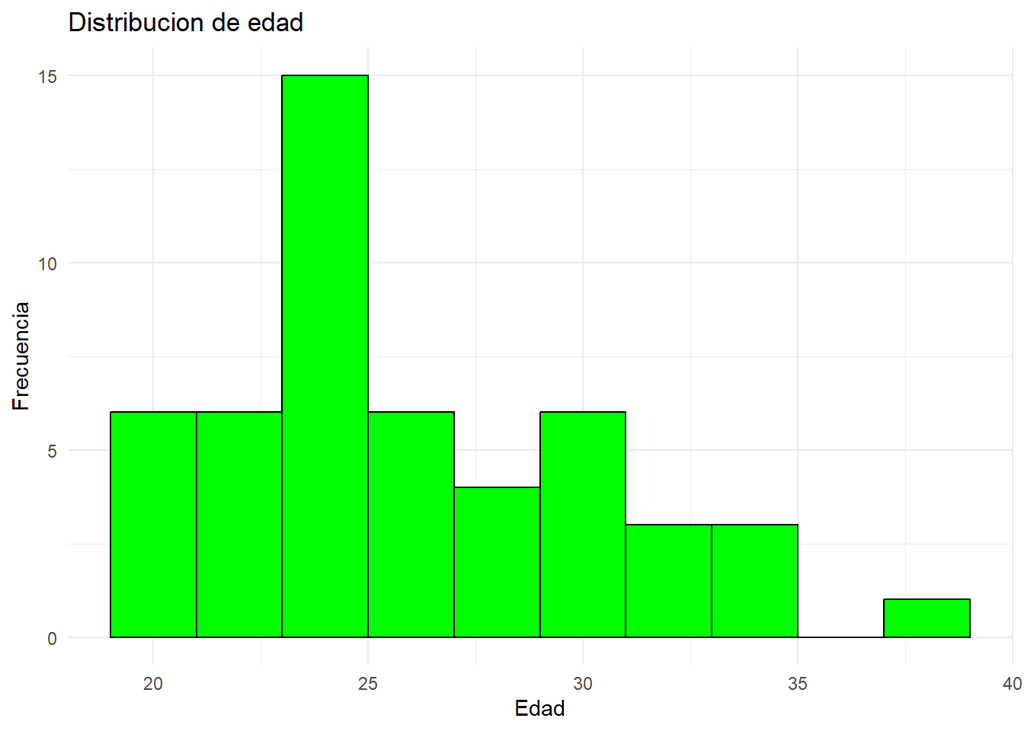

```r
# Distribucion de edad

ggplot(df, aes(x = age)) +
  geom_histogram(bins = 10, fill = "green", color = "black") +
  theme_minimal() +
  labs(title = "Distribucion de edad",
       y = "Frecuencia",
       x = "Edad")
```

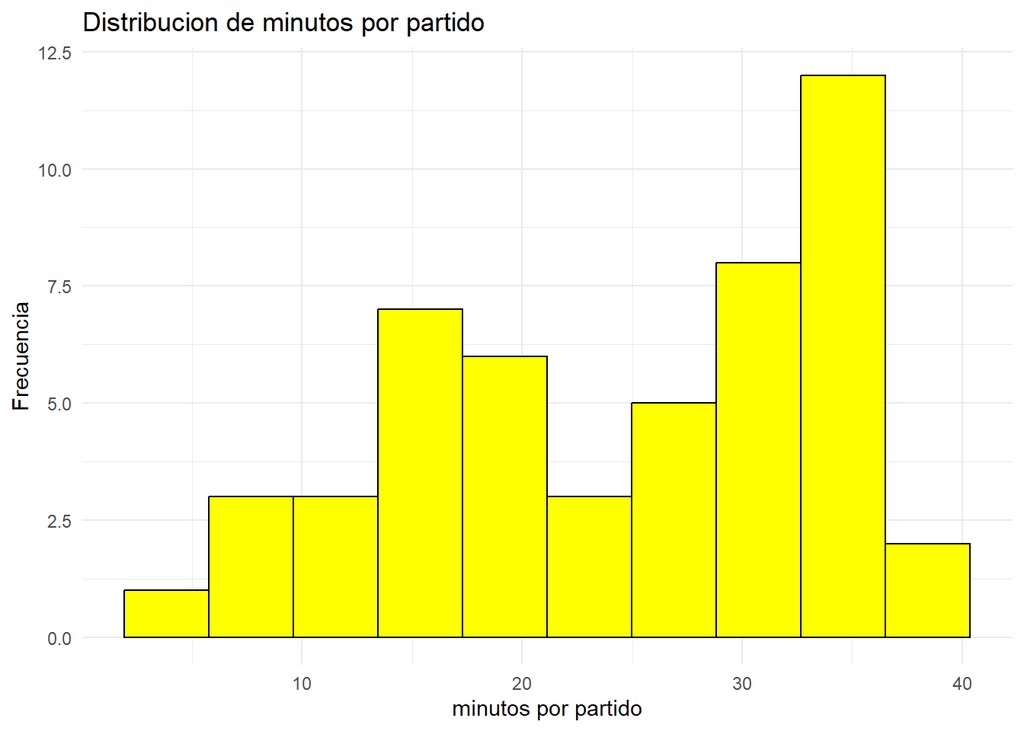

```r
# Distribucion de minutos por partido

ggplot(df, aes(x = minutes_played_per_game)) +
  geom_histogram(bins = 10, fill = "yellow", color = "black") +
  theme_minimal() +
  labs(title = "Distribucion de minutos por partido",
       y = "Frecuencia",
       x = "minutos por partido")
```

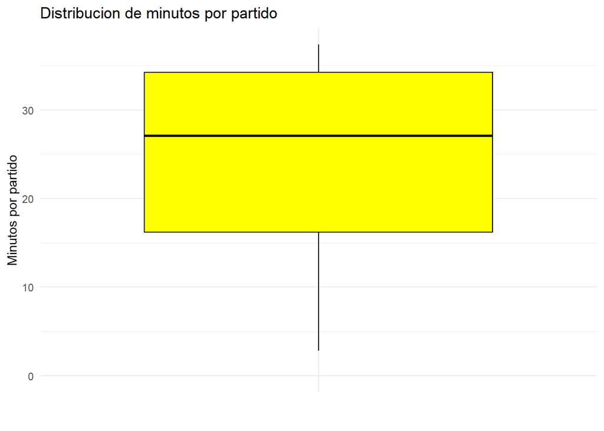

```r
ggplot(df, aes(x = "", y = minutes_played_per_game)) +
  geom_boxplot(fill = "yellow", color = "black") +
  theme_minimal() +
  labs(title = "Distribucion de minutos por partido",
       y = "Minutos por partido",
       x = "") +
  coord_cartesian(ylim = c(0, max(df$minutes_played_per_game, na.rm = TRUE)))
```

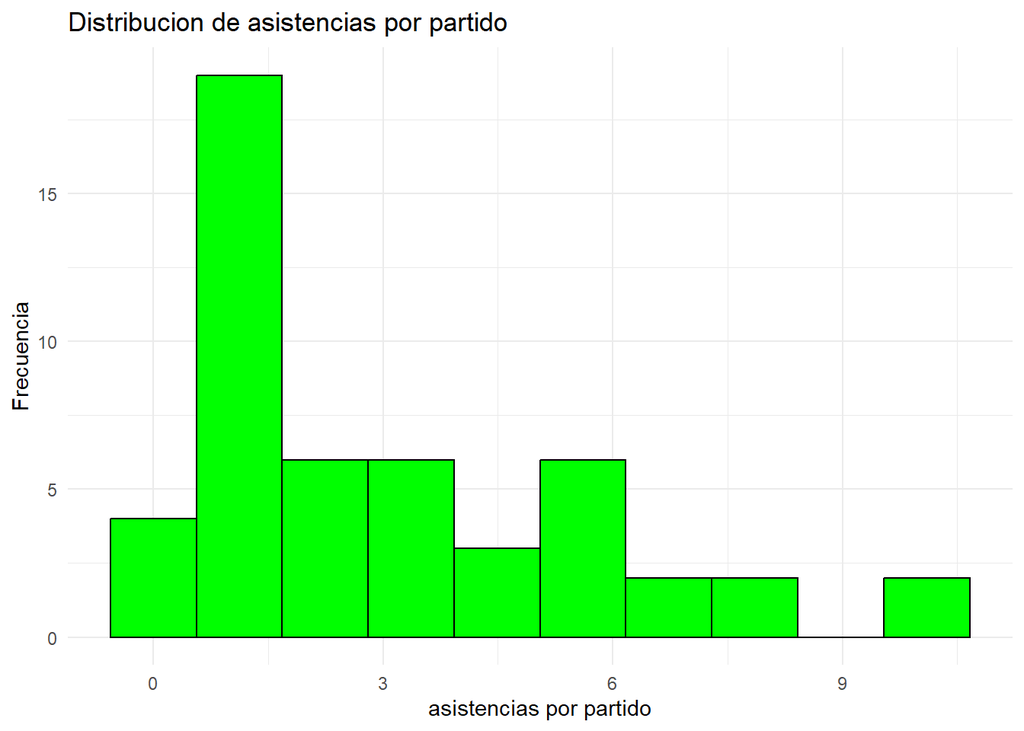

```r
# Distribucion de asistencias por partido

ggplot(df, aes(x = assists_per_game)) +
  geom_histogram(bins = 10, fill = "green", color = "black") +
  theme_minimal() +
  labs(title = "Distribucion de asistencias por partido",
       y = "Frecuencia",
       x = "asistencias por partido")
```

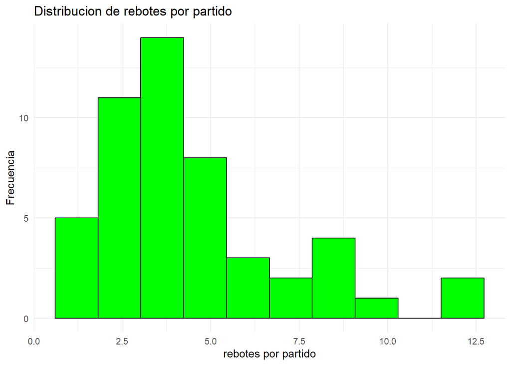

```r
# Distribucion de rebotes por partido

ggplot(df, aes(x = rebounds_per_game)) +
  geom_histogram(bins = 10, fill = "green", color = "black") +
  theme_minimal() +
  labs(title = "Distribucion de rebotes por partido",
       y = "Frecuencia",
       x = "rebotes por partido")
```

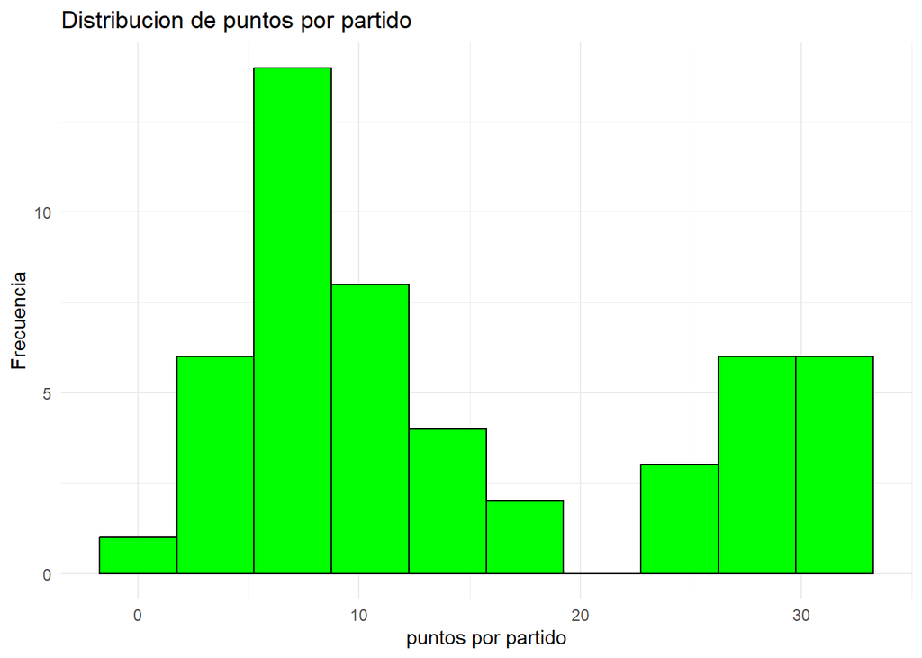

```r
# Distribucion de puntos por partido

ggplot(df, aes(x = points_per_game)) +
  geom_histogram(bins = 10, fill = "green", color = "black") +
  theme_minimal() +
  labs(title = "Distribucion de puntos por partido",
       y = "Frecuencia",
       x = "puntos por partido")
```

[figure not shown]

```r
# Notese que en este caso hay bastantes outliers.
ggplot(df, aes(y= rebounds_per_game)) +
  geom_boxplot(bins = 10, fill = "green", color = "black") +
  theme_minimal() +
  labs(title = "Distribucion de puntos por partido",
       y = "Frecuencia",
       x = "rebotes por partido")
```

```r
quantile(df$rebounds_per_game, 0.75) + (1.5 * IQR(df$rebounds_per_game))
```

```
##   75%
## 8.125
```

```r
# A partir de 8.125 rebotes por minutos ya se consideran datos atipicos por lo tanto

print(filter(df, rebounds_per_game > 8.125))
```

```
##                    name age minutes_played_per_game rebounds_per_game
## 1 Giannis Antetokounmpo  28                    32.1              11.8
## 2          Jayson Tatum  24                    36.9               8.8
## 3           Joel Embiid  28                    34.6              10.2
## 4          LeBron James  38                    35.5               8.3
## 5           Luka Dončić  23                    36.2               8.6
## 6          Nikola Jokić  27                    33.7              11.8
## 7       Lauri Markkanen  25                    34.4               8.6
##   assists_per_game points_per_game                  team   nationality
## 1              5.7            31.1    Philadelphia 76ers      Cameroon
## 2              4.6            30.1       Toronto Raptors           USA
## 3              4.2            33.1        Boston Celtics           USA
## 4              6.8            28.9          Phoenix Suns           USA
## 5              8.0            32.4      Dallas Mavericks USA/Australia
## 6              9.8            24.5 Oklahoma City Thunder           USA
```

[output cut: 17 more lines]

```r
# En este caso decidimos no eliminarlos porque de por si ya tenemos muy pocos datos.
```

#### pregunta 2.

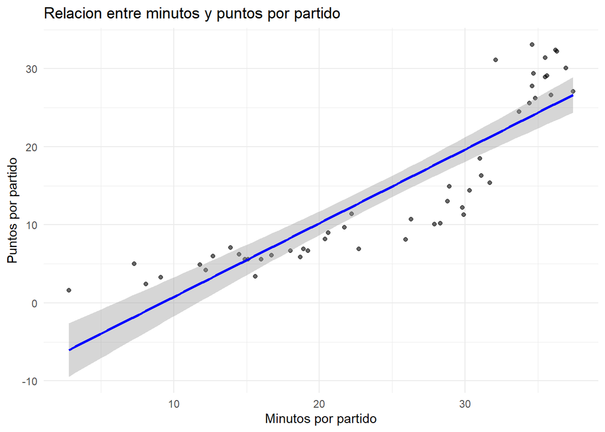

```r
ggplot(df, aes(x = minutes_played_per_game, y = points_per_game)) +
  geom_point(alpha = 0.6) +
  geom_smooth(method = "lm", color = "blue") +
  theme_minimal() +
  labs(title = "Relacion entre minutos y puntos por partido",
       x = "Minutos por partido",
       y = "Puntos por partido")
```

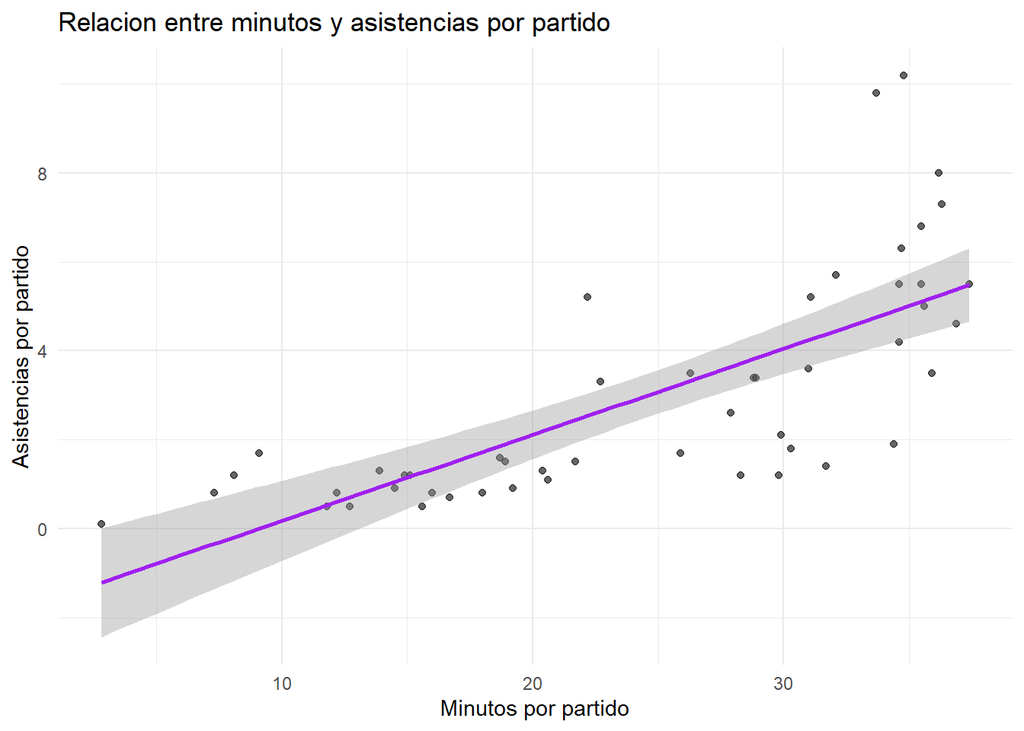

```r
ggplot(df, aes(x = minutes_played_per_game, y = assists_per_game)) +
  geom_point(alpha = 0.6) +
  geom_smooth(method = "lm", color = "purple") +
  theme_minimal() +
  labs(title = "Relacion entre minutos y asistencias por partido",
       x = "Minutos por partido",
       y = "Asistencias por partido")
```

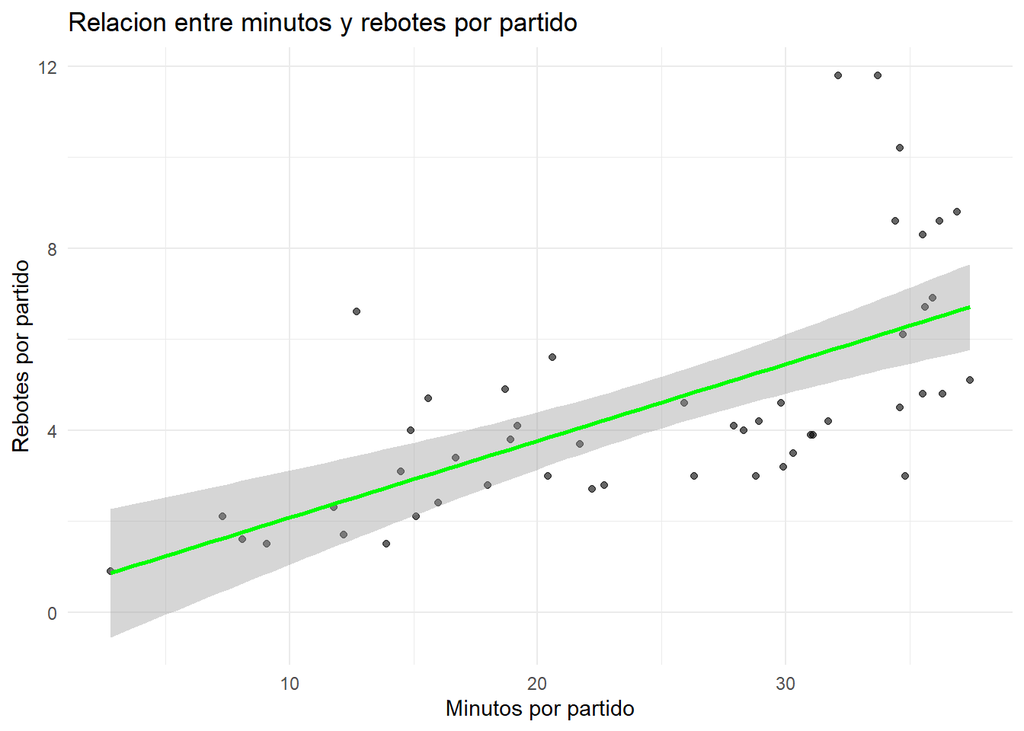

```r
ggplot(df, aes(x = minutes_played_per_game, y = rebounds_per_game)) +
  geom_point(alpha = 0.6) +
  geom_smooth(method = "lm", color = "green") +
  theme_minimal() +
  labs(title = "Relacion entre minutos y rebotes por partido",
       x = "Minutos por partido",
       y = "Rebotes por partido")
```

```r
df_numeric <- df %>% select(where(is.numeric))
```

#### Pregunta 3:

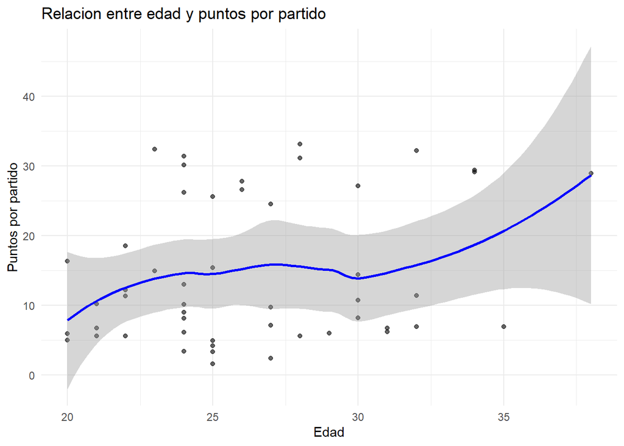

```r
ggplot(df, aes(x = age, y = points_per_game)) +
  geom_point(alpha = 0.6) +
  geom_smooth(method = "loess", color = "blue") +
  theme_minimal() +
  labs(title = "Relacion entre edad y puntos por partido",
       x = "Edad", y = "Puntos por partido")
```

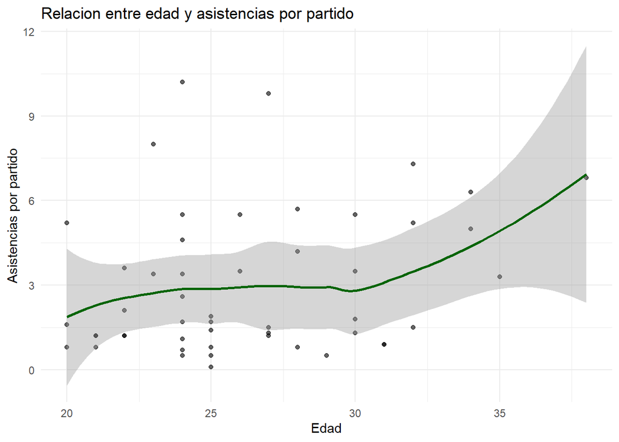

```r
ggplot(df, aes(x = age, y = assists_per_game)) +
  geom_point(alpha = 0.6) +
  geom_smooth(method = "loess", color = "darkgreen") +
  theme_minimal() +
  labs(title = "Relacion entre edad y asistencias por partido",
       x = "Edad", y = "Asistencias por partido")
```

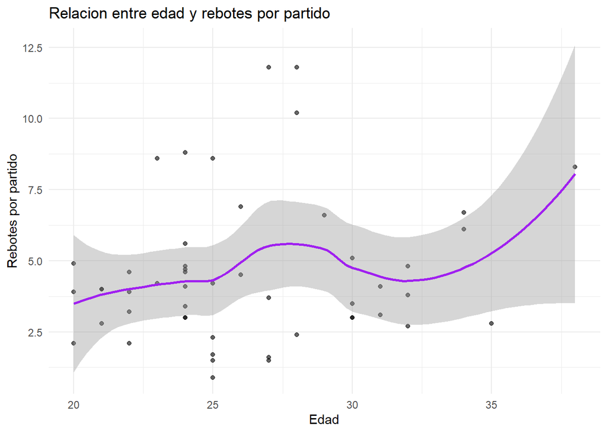

```r
ggplot(df, aes(x = age, y = rebounds_per_game)) +
  geom_point(alpha = 0.6) +
  geom_smooth(method = "loess", color = "purple") +
  theme_minimal() +
  labs(title = "Relacion entre edad y rebotes por partido",
       x = "Edad", y = "Rebotes por partido")
```

#### Pregunta 4.

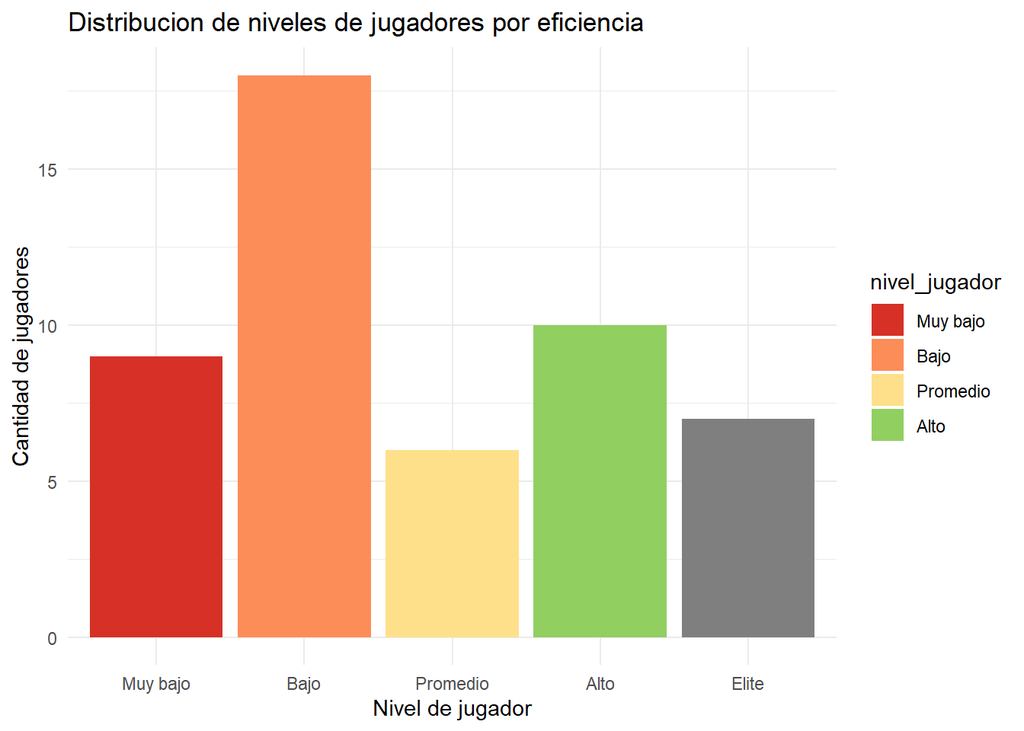

```r
ggplot(df, aes(x = nivel_jugador, fill = nivel_jugador)) +
  geom_bar() +
  scale_fill_manual(values = c(
    "Muy bajo" = "#d73027",
    "Bajo" = "#fc8d59",
    "Promedio" = "#fee08b",
    "Alto" = "#91cf60",
    "Élite" = "#1a9850"
  )) +
  labs(title = "Distribucion de niveles de jugadores por eficiencia",
       x = "Nivel de jugador", y = "Cantidad de jugadores") +
  theme_minimal()
```

```r
# jugadores con nivel elite

df_elite = df %>% filter(nivel_jugador == "Élite")
```

[output not shown]

#### Otras preguntas:

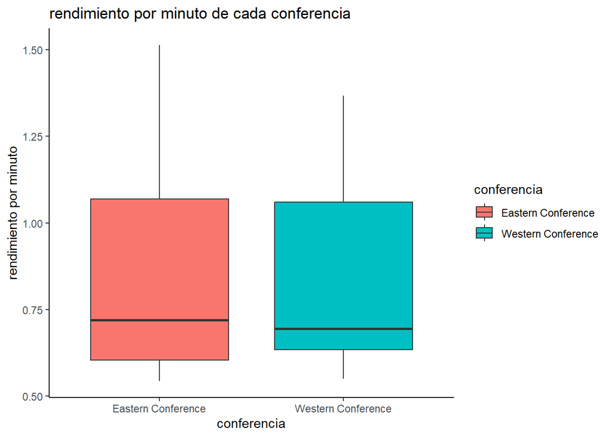

```r
ggplot(df, aes(x = conferencia, y= rendimiento_por_minuto, fill = conferencia)) +
  geom_boxplot() +
  theme_classic() +
  labs(title = "rendimiento por minuto de cada conferencia",
       x = "conferencia",
       y = "rendimiento por minuto")
```

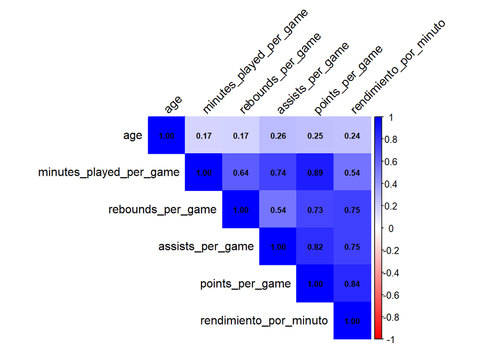

```r
# correlacion entre las variables.
cor_matrix <- cor(df_numeric, use = "complete.obs")


corrplot(cor_matrix, method = "color", type = "upper",
         tl.col = "black", tl.srt = 45,
         addCoef.col = "black", # mostrar coeficientes
         number.cex = 0.7,
         col = colorRampPalette(c("red", "white", "blue"))(200))
```

Vemos que el rendimiento por minuto de la conferencia este y oeste es igual demostrando que las conferencias tienen casi el mismo nivel. Sin embargo, los mejores jugadores se encuentran en la este.

```r
summary(df)
```

```
##      name                age        minutes_played_per_game rebounds_per_game
##  Length:50          Min.   :20.00   Min.   : 2.80           Min.   : 0.90
##  Class :character   1st Qu.:24.00   1st Qu.:16.18           1st Qu.: 3.00
##  Mode  :character   Median :25.00   Median :27.10           Median : 4.00
##                     Mean   :26.30   Mean   :24.62           Mean   : 4.55
##                     3rd Qu.:29.75   3rd Qu.:34.23           3rd Qu.: 5.05
##                     Max.   :38.00   Max.   :37.40           Max.   :11.80
##  assists_per_game points_per_game      team           nationality
##  Min.   : 0.100   Min.   : 1.600   Length:50          Length:50
##  1st Qu.: 1.200   1st Qu.: 6.125   Class :character   Class :character
##  Median : 1.750   Median :10.450   Mode  :character   Mode  :character
##  Mean   : 3.006   Mean   :14.580
##  3rd Qu.: 4.900   3rd Qu.:26.050
##  Max.   :10.200   Max.   :33.100
##     region          rendimiento_por_minuto  nivel_jugador conferencia
##  Length:50          Min.   :0.5442         Muy bajo: 9    Length:50
##  Class :character   1st Qu.:0.6113         Bajo    :18    Class :character
##  Mode  :character   Median :0.7133         Promedio: 6    Mode  :character
##                     Mean   :0.8411         Alto    :10
##                     3rd Qu.:1.0740         Elite   : 7
##                     Max.   :1.5140
```

#### **Respuestas textuales (analisis de graficas):**

1. Distribuciones

Vemos que la distibucion de la edad es variada con un sesgo en la derecha. El jugador más joven tiene 20 y el mayor, 38. La media de edad es de 26, pero una métrica con mayor representatividad sería la mediana, que presenta una edad “central” de 25 años.

```r
mode_info <- df %>%
  group_by(age) %>%
  summarise(count = n()) %>%
  filter(count == max(count))

print(mode_info)
```

```
## # A tibble: 1 × 2
##     age count
##   <int> <int>
## 1    24     9
```

#### Correlaciones Relevantes

Las variables que presentan mayor relación entre sí son (en orden descendente): - minutes_played_per_game x points_per_game: 0.89. Esto implica que entre más minutos participe un jugador, mayor puntos anotará. - points_per_game x rendimiento_por_minuto: 0.84. Esto era de esperarse porque el rendimiento se calcula con base en los puntos.

Las demás relaciones con rendimiento_por_minuto se obvian porque presentan multicolinealidad, al igual que la mencionada anteriormente.

```r
df %>% group_by(team) %>% summarise(media_edad = mean(age)) %>% arrange(media_edad)
```

```
## # A tibble: 23 × 2
##    team                  media_edad
##    <chr>                      <dbl>
##  1 Detroit Pistons             20
##  2 Memphis Grizzlies           21
##  3 New York Knicks             21.7
##  4 Charlotte Hornets           22
##  5 San Antonio Spurs           22
##  6 Atlanta Hawks               23.3
##  7 Oklahoma City Thunder       23.7
##  8 Toronto Raptors             24
##  9 Chicago Bulls               25
## 10 Washington Wizards          25
## # ℹ 13 more rows
```

El equipo con jugadores más jóvenes es Detroit Pistons, con una media de edad de 20 años.

8. ¿Qué equipo contiene a los jugadores con mayores puntos por juego?

```r
df %>%
  group_by(team) %>%
  summarise(suma_puntos = sum(points_per_game, na.rm = TRUE)) %>%
  arrange(desc(suma_puntos)) %>%
  slice_max(suma_puntos, n = 1)
```

```
## # A tibble: 1 × 2
##   team         suma_puntos
##   <chr>              <dbl>
## 1 Phoenix Suns        80.2
```

El equipo con la mayor suma de puntos por partido es: Phoenix Suns, con un total de 80.2 puntos por partido acumulados entre sus jugadores.

```r
table(df$team)
```

```
##
##         Atlanta Hawks        Boston Celtics         Brooklyn Nets
##                     3                     3                     1
##     Charlotte Hornets         Chicago Bulls      Dallas Mavericks
##                     1                     2                     6
##       Detroit Pistons Golden State Warriors  Los Angeles Clippers
##                     1                     1                     1
##    Los Angeles Lakers     Memphis Grizzlies            Miami Heat
##                     2                     1                     2
##       Milwaukee Bucks       New York Knicks Oklahoma City Thunder
##                     3                     3                     3
##         Orlando Magic    Philadelphia 76ers          Phoenix Suns
##                     2                     2                     5
##      Sacramento Kings     San Antonio Spurs       Toronto Raptors
##                     2                     1                     1
##             Utah Jazz    Washington Wizards
##                     2                     2
```

## Clusterizacion.

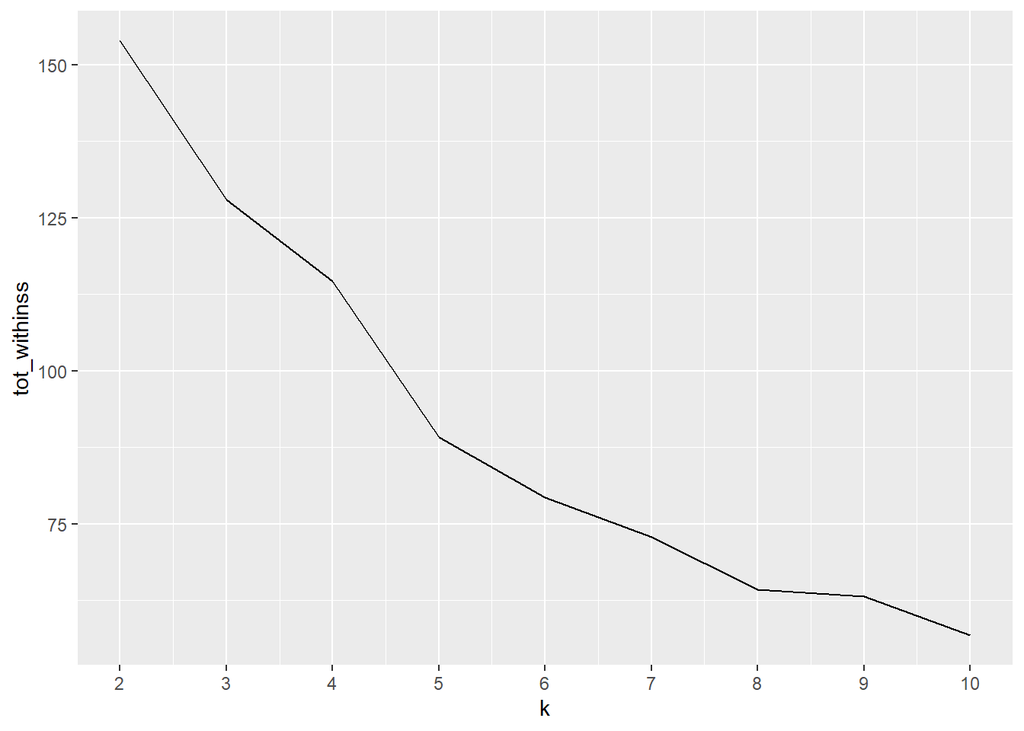

```r
set.seed(365)


df_cluster <- df[ , !(colnames(df) %in% c("nacionalidad", "nationality", "rendimiento_por_minuto", "nivel_jugador", "team"))]



cat_vars <- setdiff(
  colnames(df_cluster)[sapply(df_cluster, function(x) is.factor(x) || is.character(x))],
  "name"
)


df_dummies <- dummy_cols(df_cluster,
                         select_columns = cat_vars,
                         remove_selected_columns = TRUE,
                         remove_first_dummy = FALSE)


num_cols <- sapply(df_dummies, is.numeric) & !grepl("_", names(df_dummies))

df_dummies$name = NULL

num_cols <- c("age", "minutes_played_per_game", "rebounds_per_game", "assists_per_game", "points_per_game")
df_scaled <- scale(df_dummies[ , num_cols])

# Combinar con el resto (las columnas dummy)
df_scaled <- cbind(df_scaled, df_dummies[ , !colnames(df_dummies) %in% num_cols])

tot_withinss <- map_dbl(2:10,  function(k){
  model <- kmeans(x = df_scaled, centers = k)
  model$tot.withinss
})


elbow_df <- data.frame(
  k = 2:10 ,
  tot_withinss = tot_withinss
)


ggplot(elbow_df, aes(x = k, y = tot_withinss)) +
  geom_line() +
  scale_x_continuous(breaks = 2:10)
```

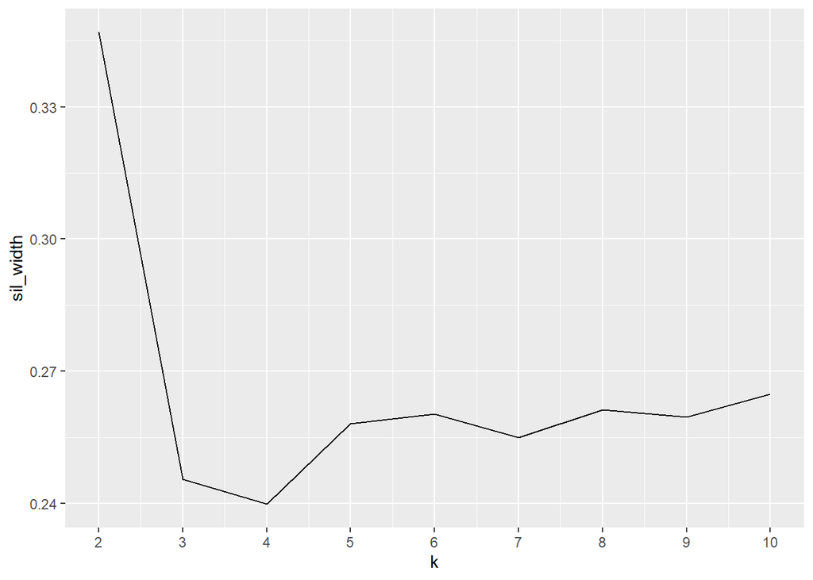

```r
sil_width <- map_dbl(2:10,  function(k){
  model <- pam(x = df_scaled, k = k)
  model$silinfo$avg.width
})


sil_df <- data.frame(
  k = 2:10,
  sil_width = sil_width
)

ggplot(sil_df, aes(x = k, y = sil_width)) +
  geom_line() +
  scale_x_continuous(breaks = 2:10)
```

```r
model_customers <- kmeans(df_scaled, centers = 6)


cluster_k <- model_customers$cluster


segment_customers_k = cbind(df_scaled, cluster_k)

segment_customers_k2 = cbind(df, cluster_k)

df = cbind(df, cluster_k)

df_scaled = cbind(df_scaled, cluster_k)


count(segment_customers_k, cluster_k)
```

```
##   cluster_k  n
## 1         1 13
## 2         2  5
## 3         3  5
## 4         4  5
## 5         5 10
## 6         6 12
```

```r
Resumen_K <- df %>%
  group_by(cluster_k) %>%
  summarise(across(where(is.numeric), mean, na.rm = TRUE))
Resumen_K
```

```
## # A tibble: 6 × 7
##   cluster_k   age minutes_played_per_game rebounds_per_game assists_per_game
##       <int> <dbl>                   <dbl>             <dbl>            <dbl>
## 1         1  24.2                    12.2              2.71            0.869
## 2         2  24.8                    35.0              6.54            7.8
## 3         3  33.6                    35.9              6.2             6.18
## 4         4  26.2                    34.8              9.26            3.98
## 5         5  30.6                    21.2              3.21            2.07
## 6         6  22.6                    27.7              4.18            2.38
## # ℹ 2 more variables: points_per_game <dbl>, rendimiento_por_minuto <dbl>
```

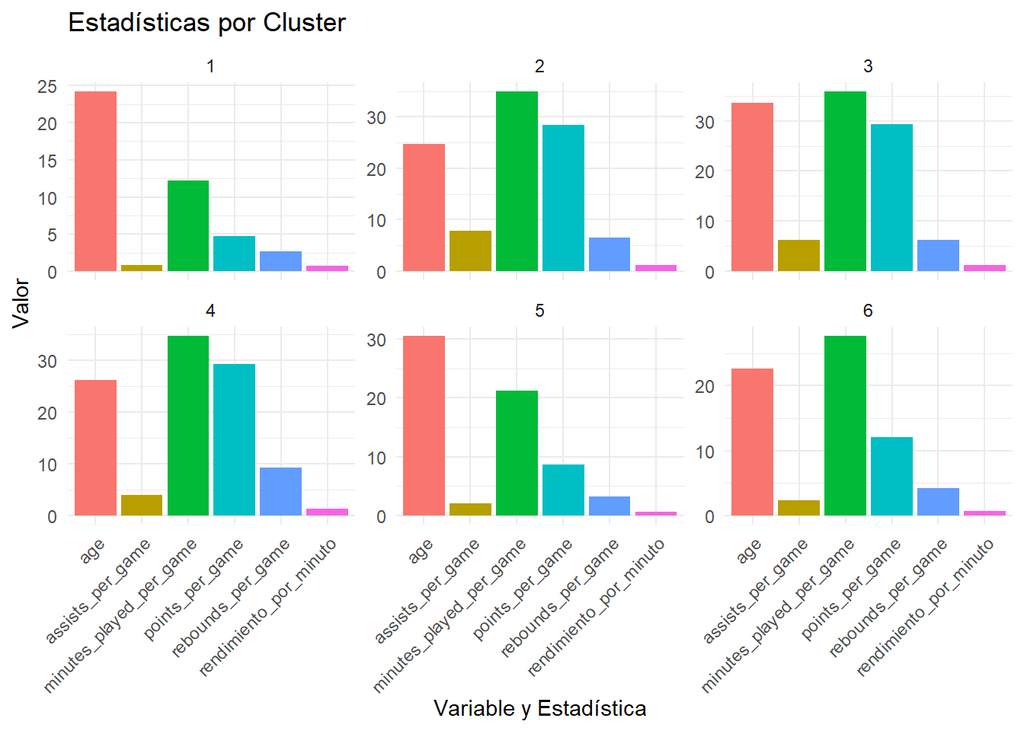

```r
Resumen_K_long <- Resumen_K %>%
  pivot_longer(
    cols = -cluster_k,
    names_to = "nombre_variable",
    values_to = "valor"
  )



ggplot(Resumen_K_long, aes(x = nombre_variable, y = valor, fill = nombre_variable )) +
  geom_bar(stat = "identity", show.legend = FALSE) +
  facet_wrap(~ cluster_k, scales = "free_y") +
  labs(
    title = "Estadísticas por Cluster",
    x = "Variable y Estadística",
    y = "Valor"
  ) +
  theme_minimal() +
  theme(axis.text.x = element_text(angle = 45, hjust = 1))
```

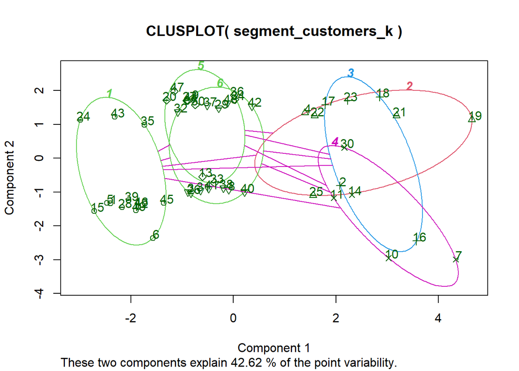

```r
clusplot(segment_customers_k,segment_customers_k$cluster_k,shape=TRUE,color=TRUE,labels=2)
```

```r
write.csv(df, "df_clusterizado.csv", row.names = FALSE, fileEncoding = "latin1")

write.csv(df_scaled, "df_scaled.csv", row.names = FALSE, fileEncoding = "latin1")

df_scaled
```

```
##            age minutes_played_per_game rebounds_per_game assists_per_game
## 1  -0.30291291              -1.2883892       -1.11568352       -0.8712646
## 2   1.32815662               1.2108204        0.09786698        1.6959249
## 3  -0.53592285              -0.4172954        0.41104130       -0.7527790
## 4  -0.06990298               1.0345276       -0.01957340        0.9850109
## 5  -0.30291291              -1.6098643       -1.19397710       -0.5158076
## 6  -0.30291291              -1.3298699       -0.88080278       -0.9897503
## 7   0.39611689               0.7752735        2.83814229        1.0640013
## 8  -0.76893278               0.4434282       -0.13701377        0.1556112
## 9   1.32815662              -0.5935882       -0.29360093       -0.5947981
## 10 -0.06990298               1.1693397        0.91994957        0.1951064
## 11 -0.53592285               1.2730414        1.66373859        0.6295539
## 12 -0.53592285              -0.9358036        0.05872019       -0.9897503
## 13  2.02718642              -0.1995220       -0.68506883        0.1161160
## 14  0.39611689               1.0345276        2.21179365        0.4715730
```

[output cut: 189 more lines]

Cluster 1: Rookie Invisible Este grupo está compuesto por jugadores jóvenes, con una edad promedio de aproximadamente 24 años. Su tiempo en cancha es reducido y su rendimiento por minuto es bajo, lo que indica una participación limitada y poco impacto en el juego.

Cluster 2: Explosivo Emergente En este grupo se encuentran jugadores también jóvenes, con una edad cercana a los 25 años. Se destacan por su alta actividad en el campo, reflejada en muchas asistencias y puntos, así como un rendimiento general elevado.

Cluster 3: Leyenda Activa Este grupo lo conforman jugadores con mayor edad, alrededor de los 33 años. A pesar de su veteranía, tienen una presencia significativa en el juego con muchos minutos disputados, un buen rendimiento y un número considerable de asistencias.

Cluster 5: Pieza Silenciosa Este cluster incluye jugadores mayores, cerca de los 30 años. Su tiempo en cancha es moderado y su rendimiento se considera medio-bajo, cumpliendo un rol menos protagónico dentro del equipo.

Cluster 6: Relevo Estratégico Este grupo está formado por jugadores muy jóvenes, con una edad aproximada de 22 años. Aunque tienen minutos medios en cancha, sus estadísticas generales y rendimiento son modestos, lo que sugiere un papel de apoyo dentro del equipo.